# SCALE R Coding Dojo

# Mutate

Verändert Spalten durch Anwenden einer Funktion oder setzen einer Konstanten:

## Syntax

```r
mutate(dataframe, column = function(column), column2 = function(column2), ...)
```

## Beispiele

```r
mutate(df, metric = 'page_impressions') # Setzt metric auf konstanten Wert
mutate(df, value = normalize(value)) # Wender normalize() auf value an
```

# Filter

Wählt Zeilen aus einem Dataframe aus, die einem oder mehreren Prädikaten entsprechen

## Syntax

```r
filter(dataframe, predicate, ...)
```

## Beispiele

```r
filter(dataframe, value >= 0) #
```

### Alle Einträge innerhalb eines Zeitraumes

```r
filter(dataframe, value >= 0, timestamp %in% c(as.POSIXct('10.10.2016'), as.POSIXct('11.10.2016')))
```

# Slice

Wählt Zeilen nach Position aus:

## Syntax

```r
slice(dataframe, from:to)
```

## Beispiel

Wähle die ersten 10 Einträge aus

```r
slice(df, 1:10)
```

# Arrange

Sortiert Zeilen neu:

## Syntax

```r
arrange(dataframe, column, ...)
```

## Beispiel

Sortiere nach Zeitstempel

```r
arrange(df, timestamp)
```

Sortiere nach Zeitstempel und gemessenem Wert

```r
arrange(df, timestamp, value)
```

# Select

Wählt Spalten aus

## Syntax

```r
select(dataframe, column, ...)
```

## Beispiel

Wähle *value* und *timestamp* aus

```r
select(df, value, timestamp)
```

Wähle alle Spalten außer *target* aus

```r
select(df, -c(target))
```

# Rename

Benennt Spalten um. Im Gegensatz zu **select** bleiben die restlichen Spalten erhalten.

## Syntax

```r
rename(df, old_name = new_name)
```

## Beispiel

Bennennt die Spalten folgendermaßen um:

- **value** in **pi_per_secs**
- **timestamp** in **date**

```r
rename(df, value = pi_per_secs, timestamp = date)
```

# GroupBy

Gruppiert die Zeilen nach einer Spalte. Diese *muss* diskret sein (z.B Strings, Integer). Ein DataFrame kann dann gruppenweise bearbeitet werden

## Syntax

```r
group_by(df, column1, ...)
```

```r
group_by(df, lhotse_vertical)
```

# ggplot2

- Erweitert die Standard Funktionen, die R für Plotting bereitstellt
- Basierend auf dem Artikel *Grammar of Graphics*
- Integration mit Data Frames

```r
install.packages('ggplot2')
```

# ggplot2 - Grundlagen

- `ggplot()` erstellt nur den leeren Plot
- `aes(x = .., y=..)` steht für Aesthetics (x- und y-Achse sowie zusätzliche Parameter)
- Diagramme werden mit `+` zum Graphen hinzugefügt und bekommen Data Frame vererbt

Das Schema für einfache Diagramme ist immer das selbe:

```r
library(ggplot2)
df <- ...
ggplot(df, aes(x = ..., y = ...)) +
  geom_line() +
  xlab('X Axis Name') +
  ylab('Y Axis Name') +
  ggtitle('Plot Title')
```

# ggplot2 - Aesthetics

Die `aes` Funktion nimmt folgende Parameter entgegen, um den Plot zu rendern

- `x` Die Spalte, die die Werte der x-Achse definiert
- `y` Die Spalte, die die Werte der y-Achse definiert
- `color` Die Spalte, die der farbigen Markierung der Werte dient (umrandet lediglich)
- `fill` Ähnlich `color`, füllt aber aus
- `group` Welche Spalte als Gruppierungsspalte dient

# ggplot2 - Liniendiagramme

- Falls die x-Achse ein Datumstyp ist (z.B Date oder POSIXct), erkennt ggplot dies
- `geom_point` kann zusätzlich benutzt werden, um die Datenpunkte zu markieren

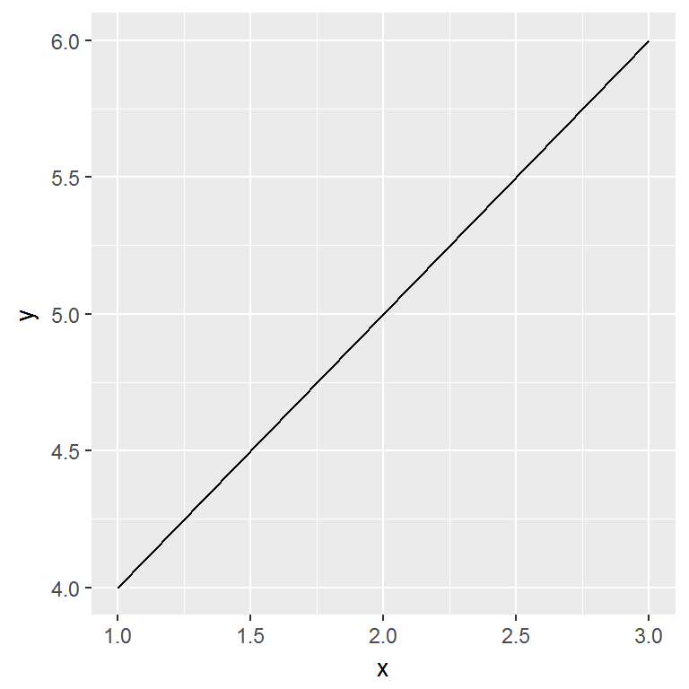

```r
library(ggplot2)
ggplot(df_plot, aes(x = x, y = y)) +
  geom_line()
```

# ggplot2 - Speichern und Anzeigen

## Speichern

```r
my_plot <- ggplot(....)
ggsave(filename, plot = my_plot, devide = 'png') # oder auch gif, jpg für device
```

## Anzeigen

```r
my_plot <- ggplot(....)
print(my_plot)
```